# Stratify, Summarise, and Compare

Your Group Names Here!

Due: October 29, 2019

Today we’ll consider measurements of people’s full expiratory lung volume collected as part of a study to understand the functional effects of smoking and exposure to second-hand smoke. The data from Kahn (2005) are available in the expiration.csv file. The unit of observation is a person. There are 654 rows of five variables: age, expiratory lung volume, height, sex, and whether or not the person smokes.

**1. Read in the data and inspect the variables the researchers collected.**

What units do you believe height is in? How old were the individuals they examined?  
What units do you believe volume is in?

```r
library(tidyverse)
library(knitr)
library(broom)

lungs <- read_csv("data/expiration.csv")
```

To start, let’s create a summary table of the lung expiratory volume for each smoking status. It’s “typical” to display the mean, median, and standard deviations for each group. To do this, we need to carry out the following steps:

- using the data, create groups of the categorical variable
- create summaries for each group

With `dplyr` it’s as easy as that! Let’s see how it’s done.

```r
lungs %>%
  group_by(smoke) %>%
  summarise(mean = mean(volume),
            median = median(volume),
            sd = sd(volume)
            )
```

```
## # A tibble: 2 x 4
##   smoke       mean median    sd
##   <chr>      <dbl>  <dbl> <dbl>
## 1 non-smoker  2.57   2.46 0.851
## 2 smoker      3.28   3.17 0.750
```

```r
# You could pipe your table into the kable() function to produce a slick HTML table!
```

**1. What can you tell about the lung expiratory volume from the table?** **What information is missing that you’d like to know more about?**

**2. Create a visualization of the lung expiratory volume by smoking status.**

**3. Does the relationship you see in the plot above make sense? Why or why not?**

Since a high lung volume is considered healthy, does this mean that smoking can improve health? What might we be ignoring that also impacts lung volume?

**4. Create a summary table (like before) of the ages within each smoking group.**  
Include the minimum, first quantile, median, third quantile, and maximum.

It looks like half of the children they collected data on who smoked were young teenager, whereas the non-smoker children were largely in their pre-teens. Let’s create a new variable named `age_cat`, which contains categorical levels of the age variable. Let’s use the following levels for the variable:

- infant (0-1 year)
- toddler (2-3 years)
- preschooler (4-5 years)
- middle childhood (6-11 years)
- pre-teen (12-14 years)
- teenager (15-19 years)

I’ll start you off and your group can finish the rest.

```r
lungs <- lungs %>%
   mutate(age_cat = case_when(age <= 1 ~ "infant",
                              age > 1 & age <= 3 ~ "toddler",
                              age > 3 & age <= 5 ~ "preschooler",
                              age > 5 & age <= 11 ~ "middle childhood",
                              age > 11 & age <= 14 ~ "pre-teen",
                              age > 14 ~ "teenager"
                              # delete this and add additional levels here!
                              ))
```

```r
lungs <- lungs %>%
  mutate(age_cat = case_when(age <= 1 ~ "infant",
                             age > 1 & age <= 3 ~ "toddler",
                             age > 3 & age <= 5 ~ "preschooler",
                             # delete this and add additional levels here!
                             ))
```

**5. Now, create a visualization of the lung expiratory volume by smoking status AND age group.** **Change the labels for *every* variable on the plot (x, y, color).**

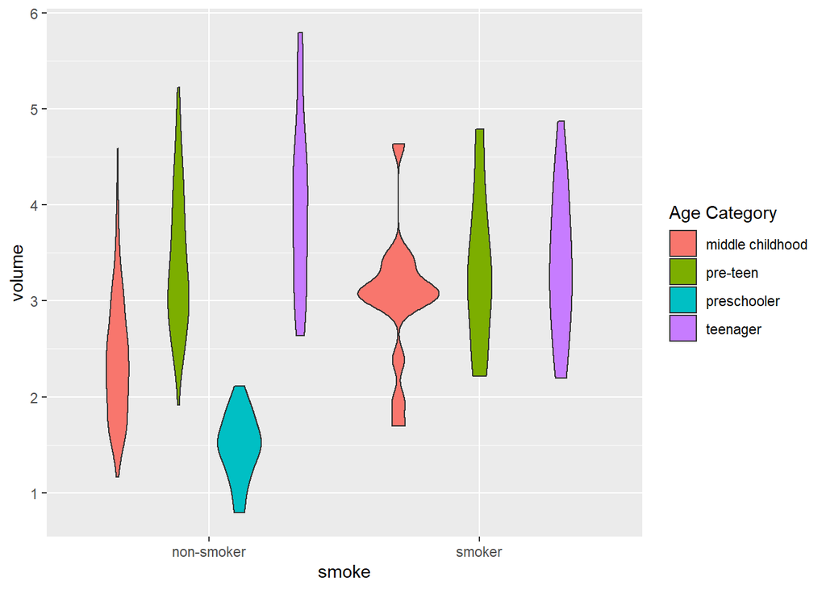

```r
lungs %>%
  ggplot(aes(x = smoke, y = volume, fill = age_cat)) +
  geom_violin() +
  labs(fill = "Age Category")
```

From the legend you can see that there are four strata for age groups in these data. Yet not every age group shows up for each smoking status.

**6. Explain, in everyday terms, why some of the age strata are missing.**

# Estimation

Researchers were interested in estimating how different the the lung expiratory volume of smokers and non-smokers is, after accounting for age.

**7. What analysis approach would you recommend? How would age be included in your model?**

## Additive Model

Let’s start with an additive ANOVA model.

```r
# ANOVA model where smoking status
smoke_lm <- lm(volume ~ smoke + age_cat, data = lungs)

# tidy() lives in the broom package
# it creates a tidy table from the output of an lm() or anova() object
tidy(smoke_lm)
```

```
## # A tibble: 6 x 5
##   term               estimate std.error statistic   p.value
##   <chr>                 <dbl>     <dbl>     <dbl>     <dbl>
## 1 (Intercept)         2.41       0.0319   75.4    6.00e-323
## 2 smokesmoker         0.00316    0.0965    0.0327 9.74e-  1
## 3 age_catpre-teen     0.975      0.0699   14.0    6.35e- 39
## 4 age_catpreschooler -0.923      0.114    -8.08   3.16e- 15
## 5 age_catteenager     1.30       0.109    11.9    7.81e- 30
## 6 age_cattoddler     -1.17       0.473    -2.47   1.36e-  2
```

```r
tidy(
  anova(smoke_lm)
  )
```

```
## # A tibble: 3 x 6
##   term         df sumsq meansq statistic   p.value
##   <chr>     <int> <dbl>  <dbl>     <dbl>     <dbl>
## 1 smoke         1  29.6 29.6        66.4  1.91e-15
## 2 age_cat       4 173.  43.2        97.0  1.19e-64
## 3 Residuals   648 289.   0.445      NA   NA
```

What age group is the baseline for this model? (hint: What level is missing from the output?)

**8. What is the estimated change in lung expiratory volume for a child who is a teenager, as compared to a child in the middle of their childhood? Does this make sense?**

**9. What is the estimated change in the lung expiratory volume for a smoker as compared to a non-smoker? Does this make sense?**

**10. In the summary table, the p-value for the adjustment to the mean lung expiratory volume for smokers has a large p-value. Does that mean smoker should be removed from the model? Why or why not?**

## Interactive Model

Alright, maybe an interactive ANOVA model is a better option.

```r
# ANOVA model where smoking status
interact_lm <- lm(volume ~ smoke*age_cat, data = lungs)

# tidy() lives in the broom package
# it creates a tidy table from the output of an lm() or anova() object
tidy(interact_lm)
```

```
## # A tibble: 8 x 5
##   term                        estimate std.error statistic   p.value
##   <chr>                          <dbl>     <dbl>     <dbl>     <dbl>
## 1 (Intercept)                    2.39     0.0318     75.1  2.38e-321
## 2 smokesmoker                    0.643    0.172       3.73 2.05e-  4
## 3 age_catpre-teen                1.02     0.0735     13.8  2.79e- 38
## 4 age_catpreschooler            -0.902    0.112      -8.02 5.01e- 15
## 5 age_catteenager                1.61     0.133      12.1  1.20e- 30
## 6 age_cattoddler                -1.15     0.465      -2.47 1.37e-  2
## 7 smokesmoker:age_catpre-teen   -0.728    0.224      -3.26 1.19e-  3
## 8 smokesmoker:age_catteenager   -1.25     0.255      -4.90 1.23e-  6
```

**11. Using the model output, fill in the table with the estimated expiratory lung volumes for pre-teens who smoke and teenagers who do not smoke.**

| Age | Smoker | Estimated Mean Lung Expiratory Volume |
| --- | --- | --- |
| toddler | Yes | 1.883 |
| preschooler | Yes | 2.131 |
| middle childhood | Yes | 3.033 |
| pre-teen | Yes |  |
| teenager | Yes | 3.393 |
| toddler | No | 1.24 |
| preschooler | No | 1.488 |
| middle childhood | No | 2.39 |
| pre-teen | No | 3.41 |
| teenager | No |  |